# 20250814_R1_vcf_filter

2025-08-14

## VCF filtering - Figure 2a,b

In previous version, we have:

> “In total, 10,041 variants, with an allele frequency (AF) higher than 0.05, were identified at 6,097 different positions across all evolved populations (including the solvent-control conditions), with a median of 28 variants (Figures 2a; EV4a, b).”

According to our discussion last time (Simone, Sonja, Rui; 2025.08.06); we are filtering variants that were appeared in both control and xenobiotic groups; as those are highly likely to be *pre-exist* variants.

We have mentioned/discussed this in the past that **variants** we identified includes: 1) newly emerged mutations 2) pre-exist genetic variants emerged / sequenced due to increased ratio in population

One reason we have the above 2) is our parental strain **was not** single colony.

Now, with new filtering:

1. Ref + Alt depth >= 20;
2. Alt depth >= 5; **this filtered out the most of the variants**
3. Positions with prevalence < 24 (i.e. max. appeared in 3 diff. xenobiotics) `this will be refined`

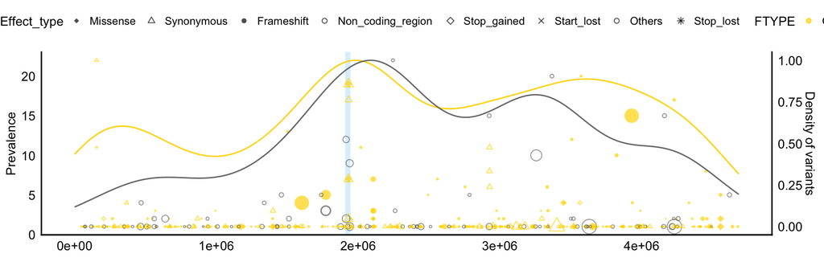

After filtering, 868 variants in 422 positions were remained. As we can see, most of them appeared in one sample.

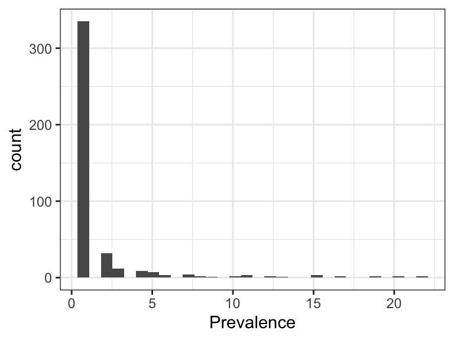

|  | Effect | POS | Prevalence | Average_AF | FTYPE | Effect_type | Shape |
| --- | --- | --- | --- | --- | --- | --- | --- |
| 3 | frameshift_variant | 3507723 | 12 | 0.06811313 | CDS | Frameshift | 16 |
| 14 | frameshift_variant | 3573073 | 20 | 0.06251616 | CDS | Frameshift | 16 |
| 29 | frameshift_variant | 4229448 | 17 | 0.07238856 | CDS | Frameshift | 16 |
| 32 | frameshift_variant | 3823393 | 10 | 0.08734676 | CDS | Frameshift | 16 |
| 40 | frameshift_variant | 3929789 | 15 | 1.00000000 | CDS | Frameshift | 16 |
| 41 | frameshift_variant | 1501343 | 13 | 0.06485431 | CDS | Frameshift | 16 |
| 48 | frameshift_variant | 2019520 | 11 | 0.06262066 | CDS | Frameshift | 16 |
| 66 | missense_variant | 154726 | 11 | 0.06486927 | CDS | Missense | 18 |
| 215 | missense_variant | 1932344 | 19 | 0.24309935 | CDS | Missense | 18 |
| 266 | Non-coding_region_variant | 2245651 | 22 | 0.06171542 | Non-coding | Non_coding_region | 1 |

[output cut: 9 more lines]

## VCF filtering - Figure 2a,b

Plot the prevalence of variants in SusC/D region

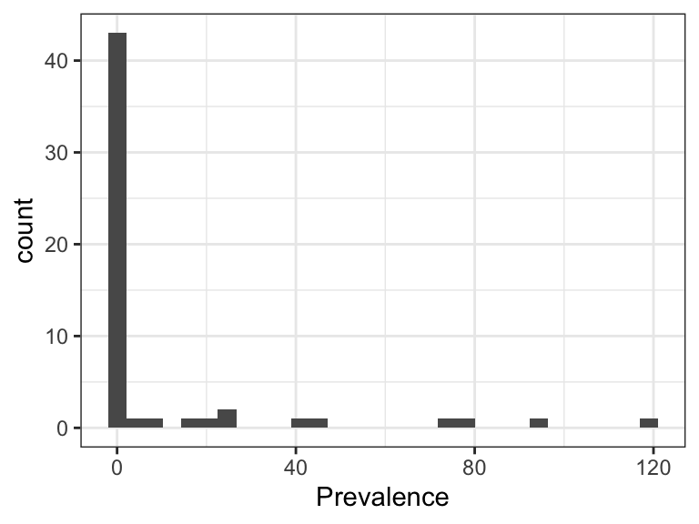

As we can see, most of the variants appeared in one sample, we will plot these only below:

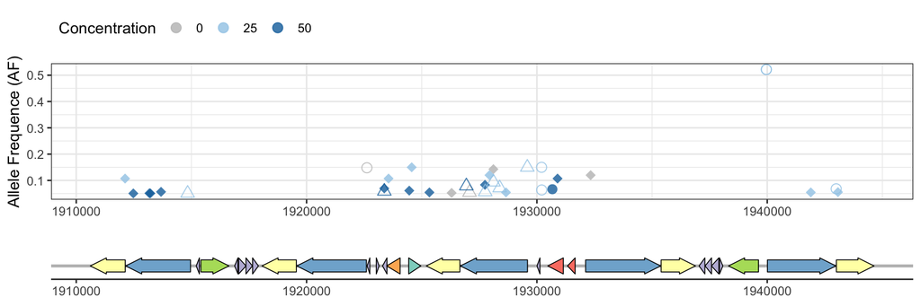